# Práctica final

## Ejercicio 4

Comparar las ventas entre Madrid y Barcelona.

Teníamos creado este dataframe:

```r
dfMadBcn=df %>%
  filter(GrupoProvincia=="BCN" | GrupoProvincia=="MAD") %>%
  mutate(
        GrupoProvincia=droplevels(GrupoProvincia)
        )


table(dfMadBcn$GrupoProvincia)
```

```
##
## MAD BCN
## 470 542
```

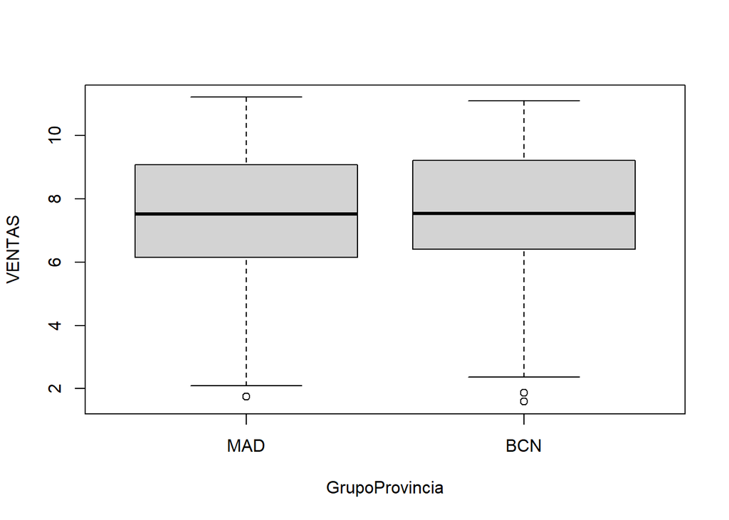

```r
plot(VENTAS~GrupoProvincia,dfMadBcn)
```

```r
res <- compareGroups(GrupoProvincia ~ VENTAS, data = dfMadBcn, method = 4)
restab <- createTable(res, show.p.overall = F)
export2md(restab, format = "html")
```

Summary descriptives table by groups of `GrupoProvincia’

|  | MAD | BCN |
| --- | --- | --- |
|  | N=470 | N=542 |
| VENTAS | 7.52 [6.15;9.07] | 7.53 [6.41;9.20] |

Tras observar el boxplot y la tabla de compareGroups, vemos que las ventas en ambas provincias son muy similares ya que la mediana es muy parecida y los cuartiles también.

```r
wilcox.test(VENTAS~GrupoProvincia,dfMadBcn)
```

```
##
##  Wilcoxon rank sum test with continuity correction
##
## data:  VENTAS by GrupoProvincia
## W = 122328, p-value = 0.277
## alternative hypothesis: true location shift is not equal to 0
```

La hipotesis nula sería que no hay asociación entre ventas y la provincia Madrid o Barcelona. Vemos que debemos aceptar esa hipótesis y eso también nos sirve para confirmar que con nuestros datos, no podemos decir que las ventas de Madrid y Barcelona sean diferentes.

## Ejercicio 5

Presentación del modelo de predicción de las ventas para el siguiente año y describirla adecuadamente.

Creamos un modelo predictivo de ventas con todas las variables del dataframe donde hemos eliminado los outliers (dfnew). Vamos a eliminar la variable Productiviad ya que finalmente concluimos que no ibamos a usar dicha variable porque se calcula a partir del valor de ventas.

```r
dfnew=dfnew %>%

select(-PRODUCTIVIDAD)
```

```r
full.model=lm(VENTAS ~ .,dfnew)
summary(full.model)
```

```
##
## Call:
## lm(formula = VENTAS ~ ., data = dfnew)
##
## Residuals:
##     Min      1Q  Median      3Q     Max
## -5.6858 -0.6117  0.0988  0.5929  4.3804
##
## Coefficients:
##                           Estimate Std. Error t value Pr(>|t|)
## (Intercept)              4.0952860  0.1952055  20.979  < 2e-16 ***
## rentabieco               0.0136005  0.0012041  11.295  < 2e-16 ***
## rentabifin               0.0009637  0.0002395   4.023 5.84e-05 ***
## endp                     0.2061182  0.0392044   5.258 1.53e-07 ***
## liq                      0.1172859  0.0290598   4.036 5.53e-05 ***
## nempleados               1.0304563  0.0146591  70.295  < 2e-16 ***
## edad                    -0.0259780  0.0216614  -1.199   0.2305
## conce                    0.1467134  0.0111103  13.205  < 2e-16 ***
## numest                   0.2794275  0.0336923   8.294  < 2e-16 ***
## estpYes                  0.0484470  0.0896123   0.541   0.5888
## GrupoProvinciaBCN        0.1316312  0.0628620   2.094   0.0363 *
## GrupoProvinciaMuyGrande -0.0356106  0.0537521  -0.662   0.5077
## GrupoProvinciaGrande     0.0563234  0.0571316   0.986   0.3243
## GrupoProvinciaMediana    0.0952482  0.0601928   1.582   0.1136
## ---
## Signif. codes:  0 '***' 0.001 '**' 0.01 '*' 0.05 '.' 0.1 ' ' 1
##
## Residual standard error: 0.9799 on 4372 degrees of freedom
## Multiple R-squared:  0.6966, Adjusted R-squared:  0.6957
## F-statistic: 772.1 on 13 and 4372 DF,  p-value: < 2.2e-16
```

Veo que hay variables que no son significativas en mi modelo: edad, est. El R^2 ajustado es 0.6957

```r
car::vif(full.model)
```

```
##                    GVIF Df GVIF^(1/(2*Df))
## rentabieco     1.156399  1        1.075360
## rentabifin     1.035313  1        1.017503
## endp           2.037849  1        1.427532
## liq            1.841733  1        1.357105
## nempleados     1.692222  1        1.300854
## edad           1.489252  1        1.220349
## conce          1.155696  1        1.075033
## numest         1.386115  1        1.177334
## estp           1.110018  1        1.053574
## GrupoProvincia 1.158894  4        1.018604
```

No hay valores>5. se supone que no hay multicolineallidad entre las variables independientes.

```r
step.model= stepAIC(full.model,direction="both",trace=FALSE)
summary(step.model)
```

```
##
## Call:
## lm(formula = VENTAS ~ rentabieco + rentabifin + endp + liq +
##     nempleados + conce + numest + GrupoProvincia, data = dfnew)
##
## Residuals:
##     Min      1Q  Median      3Q     Max
## -5.6979 -0.6104  0.1031  0.5934  4.3558
##
## Coefficients:
##                           Estimate Std. Error t value Pr(>|t|)
## (Intercept)              4.0141468  0.1838279  21.836  < 2e-16 ***
## rentabieco               0.0135816  0.0012039  11.281  < 2e-16 ***
## rentabifin               0.0009948  0.0002382   4.177 3.01e-05 ***
## endp                     0.2150990  0.0385494   5.580 2.55e-08 ***
## liq                      0.1183730  0.0290416   4.076 4.66e-05 ***
## nempleados               1.0227469  0.0131252  77.922  < 2e-16 ***
## conce                    0.1471399  0.0111038  13.251  < 2e-16 ***
## numest                   0.2840353  0.0324526   8.752  < 2e-16 ***
## GrupoProvinciaBCN        0.1253547  0.0626738   2.000   0.0455 *
## GrupoProvinciaMuyGrande -0.0384393  0.0536930  -0.716   0.4741
## GrupoProvinciaGrande     0.0529806  0.0570718   0.928   0.3533
## GrupoProvinciaMediana    0.0889160  0.0599617   1.483   0.1382
## ---
## Signif. codes:  0 '***' 0.001 '**' 0.01 '*' 0.05 '.' 0.1 ' ' 1
##
## Residual standard error: 0.9798 on 4374 degrees of freedom
## Multiple R-squared:  0.6965, Adjusted R-squared:  0.6957
## F-statistic: 912.4 on 11 and 4374 DF,  p-value: < 2.2e-16
```

Aplicando el criterio de AKaike vemos que esas variables se pueden eliminar y r^2 ajustado no se modifica.

Seguimos eliminando variables hasta que veamos que el R^2 disminuye significativamente:

Eliminamos la variable grupoProvincia ya que tampoco tiene a penas significancia:

```r
modelp=lm(formula = VENTAS ~  rentabieco + rentabifin + endp + liq +
    nempleados + conce + numest , data = dfnew)
summary(modelp)
```

```
##
## Call:
## lm(formula = VENTAS ~ rentabieco + rentabifin + endp + liq +
##     nempleados + conce + numest, data = dfnew)
##
## Residuals:
##     Min      1Q  Median      3Q     Max
## -5.7386 -0.6122  0.1003  0.6015  4.2930
##
## Coefficients:
##              Estimate Std. Error t value Pr(>|t|)
## (Intercept) 4.0439591  0.1758799  22.993  < 2e-16 ***
## rentabieco  0.0136417  0.0012053  11.318  < 2e-16 ***
## rentabifin  0.0009462  0.0002381   3.974 7.20e-05 ***
## endp        0.2155412  0.0385897   5.585 2.47e-08 ***
## liq         0.1220991  0.0290447   4.204 2.68e-05 ***
## nempleados  1.0221086  0.0130931  78.065  < 2e-16 ***
## conce       0.1474886  0.0105343  14.001  < 2e-16 ***
## numest      0.2794984  0.0324032   8.626  < 2e-16 ***
## ---
## Signif. codes:  0 '***' 0.001 '**' 0.01 '*' 0.05 '.' 0.1 ' ' 1
##
## Residual standard error: 0.9812 on 4378 degrees of freedom
## Multiple R-squared:  0.6953, Adjusted R-squared:  0.6948
## F-statistic:  1427 on 7 and 4378 DF,  p-value: < 2.2e-16
```

El modelo sigue con un R^2 muy parecido: 0.6948

Eliminamos la variable liquidez:

```r
modelp=lm(formula = VENTAS ~   rentabieco + rentabifin + endp  +
    nempleados + conce + numest, data = dfnew)
summary(modelp)
```

```
##
## Call:
## lm(formula = VENTAS ~ rentabieco + rentabifin + endp + nempleados +
##     conce + numest, data = dfnew)
##
## Residuals:
##     Min      1Q  Median      3Q     Max
## -5.6634 -0.6136  0.1027  0.6093  4.2621
##
## Coefficients:
##              Estimate Std. Error t value Pr(>|t|)
## (Intercept) 4.5277130  0.1332629  33.976  < 2e-16 ***
## rentabieco  0.0138893  0.0012062  11.515  < 2e-16 ***
## rentabifin  0.0009485  0.0002386   3.976 7.13e-05 ***
## endp        0.1109624  0.0295569   3.754 0.000176 ***
## nempleados  1.0174389  0.0130707  77.841  < 2e-16 ***
## conce       0.1480762  0.0105534  14.031  < 2e-16 ***
## numest      0.2771960  0.0324602   8.540  < 2e-16 ***
## ---
## Signif. codes:  0 '***' 0.001 '**' 0.01 '*' 0.05 '.' 0.1 ' ' 1
##
## Residual standard error: 0.9831 on 4379 degrees of freedom
## Multiple R-squared:  0.6941, Adjusted R-squared:  0.6937
## F-statistic:  1656 on 6 and 4379 DF,  p-value: < 2.2e-16
```

El modelo sigue con un R^2 muy parecido: 0.6937 Eliminemos ahora la variable rentabilidad financiera:

```r
modelp=lm(formula = VENTAS ~    rentabieco  + endp  +
    nempleados + conce + numest, data = dfnew)
summary(modelp)
```

```
##
## Call:
## lm(formula = VENTAS ~ rentabieco + endp + nempleados + conce +
##     numest, data = dfnew)
##
## Residuals:
##     Min      1Q  Median      3Q     Max
## -5.6551 -0.6233  0.1008  0.6083  4.2442
##
## Coefficients:
##             Estimate Std. Error t value Pr(>|t|)
## (Intercept) 4.519330   0.133471  33.860  < 2e-16 ***
## rentabieco  0.013769   0.001208  11.400  < 2e-16 ***
## endp        0.118502   0.029546   4.011 6.15e-05 ***
## nempleados  1.012717   0.013039  77.671  < 2e-16 ***
## conce       0.148426   0.010571  14.041  < 2e-16 ***
## numest      0.277508   0.032515   8.535  < 2e-16 ***
## ---
## Signif. codes:  0 '***' 0.001 '**' 0.01 '*' 0.05 '.' 0.1 ' ' 1
##
## Residual standard error: 0.9848 on 4380 degrees of freedom
## Multiple R-squared:  0.693,  Adjusted R-squared:  0.6927
## F-statistic:  1977 on 5 and 4380 DF,  p-value: < 2.2e-16
```

El modelo sigue con un R^2 muy parecido: 0.6927 Eliminemos ahora la variable endp(nivel de endeudamiento) :

```r
modelp=lm(formula =  VENTAS ~  rentabieco  + nempleados + conce +
    numest, data = dfnew)
summary(modelp)
```

```
##
## Call:
## lm(formula = VENTAS ~ rentabieco + nempleados + conce + numest,
##     data = dfnew)
##
## Residuals:
##     Min      1Q  Median      3Q     Max
## -5.8678 -0.6215  0.1012  0.6054  4.2139
##
## Coefficients:
##             Estimate Std. Error t value Pr(>|t|)
## (Intercept) 5.036474   0.034547 145.785   <2e-16 ***
## rentabieco  0.012186   0.001143  10.657   <2e-16 ***
## nempleados  1.007295   0.012991  77.540   <2e-16 ***
## conce       0.148576   0.010589  14.031   <2e-16 ***
## numest      0.280960   0.032559   8.629   <2e-16 ***
## ---
## Signif. codes:  0 '***' 0.001 '**' 0.01 '*' 0.05 '.' 0.1 ' ' 1
##
## Residual standard error: 0.9865 on 4381 degrees of freedom
## Multiple R-squared:  0.6919, Adjusted R-squared:  0.6916
## F-statistic:  2459 on 4 and 4381 DF,  p-value: < 2.2e-16
```

R^2 a penas se modifica: 0.6916 Eliminemos ahora la variable rentabilidad económica:

```r
modelp=lm(formula =  VENTAS ~     nempleados + conce +
    numest, data = dfnew)
summary(modelp)
```

```
##
## Call:
## lm(formula = VENTAS ~ nempleados + conce + numest, data = dfnew)
##
## Residuals:
##     Min      1Q  Median      3Q     Max
## -5.7671 -0.6298  0.0985  0.6123  4.2531
##
## Coefficients:
##             Estimate Std. Error t value Pr(>|t|)
## (Intercept)  5.02559    0.03497 143.700   <2e-16 ***
## nempleados   1.02631    0.01303  78.754   <2e-16 ***
## conce        0.14072    0.01070  13.154   <2e-16 ***
## numest       0.28694    0.03297   8.703   <2e-16 ***
## ---
## Signif. codes:  0 '***' 0.001 '**' 0.01 '*' 0.05 '.' 0.1 ' ' 1
##
## Residual standard error: 0.999 on 4382 degrees of freedom
## Multiple R-squared:  0.6839, Adjusted R-squared:  0.6837
## F-statistic:  3160 on 3 and 4382 DF,  p-value: < 2.2e-16
```

Seguimos eliminando variables hasta que veamos que el R^2 disminuye significativamente: Eliminamos la variable conce (número de establecimientos que ofrecen el mismo servicio a nivel municipio)

```r
modelp=lm(formula =  VENTAS ~  nempleados +  numest, data = dfnew)
summary(modelp)
```

```
##
## Call:
## lm(formula = VENTAS ~ nempleados + numest, data = dfnew)
##
## Residuals:
##     Min      1Q  Median      3Q     Max
## -5.3410 -0.6861  0.1193  0.6345  4.1085
##
## Coefficients:
##             Estimate Std. Error t value Pr(>|t|)
## (Intercept)  5.31162    0.02792  190.22   <2e-16 ***
## nempleados   1.04526    0.01320   79.17   <2e-16 ***
## numest       0.31686    0.03353    9.45   <2e-16 ***
## ---
## Signif. codes:  0 '***' 0.001 '**' 0.01 '*' 0.05 '.' 0.1 ' ' 1
##
## Residual standard error: 1.018 on 4383 degrees of freedom
## Multiple R-squared:  0.6714, Adjusted R-squared:  0.6713
## F-statistic:  4478 on 2 and 4383 DF,  p-value: < 2.2e-16
```

El valor de R^2 ahora es 0.6713

Vamos a eliminar la variable numest:

```r
modelp=lm(formula =  VENTAS ~  nempleados , data = dfnew)
summary(modelp)
```

```
##
## Call:
## lm(formula = VENTAS ~ nempleados, data = dfnew)
##
## Residuals:
##     Min      1Q  Median      3Q     Max
## -5.4770 -0.7005  0.1358  0.6328  4.6729
##
## Coefficients:
##             Estimate Std. Error t value Pr(>|t|)
## (Intercept)  5.31494    0.02820  188.47   <2e-16 ***
## nempleados   1.10286    0.01183   93.23   <2e-16 ***
## ---
## Signif. codes:  0 '***' 0.001 '**' 0.01 '*' 0.05 '.' 0.1 ' ' 1
##
## Residual standard error: 1.029 on 4384 degrees of freedom
## Multiple R-squared:  0.6647, Adjusted R-squared:  0.6646
## F-statistic:  8691 on 1 and 4384 DF,  p-value: < 2.2e-16
```

El valor de R^2 ahora es 0.6646.

Finalmente vamos a optar por seleccionar el modelo predictivo de ventas en funcion de las variables número de empleados (nempleados), número de establecimientos que ofrecen el mismo servicio a nivel municipio (conce) y número de establecimientos por empresa (numest).

Con este modelo predictivo final podemos explicar el 68.4% de la variabilidad de Ventas.

Podríamos elegir un modelo con menos variables perdiendo un 1 o 2% de explicabilidad. Sin embargo, consideramos que un modelo con 3 variables es bastante viable y estable y no queremos renunciar a ese 2% de explicabilidad de ventas.

```r
modelofinal=lm(formula =  VENTAS ~   nempleados+conce+numest , data = dfnew)
summary(modelofinal)
```

```
##
## Call:
## lm(formula = VENTAS ~ nempleados + conce + numest, data = dfnew)
##
## Residuals:
##     Min      1Q  Median      3Q     Max
## -5.7671 -0.6298  0.0985  0.6123  4.2531
##
## Coefficients:
##             Estimate Std. Error t value Pr(>|t|)
## (Intercept)  5.02559    0.03497 143.700   <2e-16 ***
## nempleados   1.02631    0.01303  78.754   <2e-16 ***
## conce        0.14072    0.01070  13.154   <2e-16 ***
## numest       0.28694    0.03297   8.703   <2e-16 ***
## ---
## Signif. codes:  0 '***' 0.001 '**' 0.01 '*' 0.05 '.' 0.1 ' ' 1
##
## Residual standard error: 0.999 on 4382 degrees of freedom
## Multiple R-squared:  0.6839, Adjusted R-squared:  0.6837
## F-statistic:  3160 on 3 and 4382 DF,  p-value: < 2.2e-16
```

Veamos los errores del modelo:

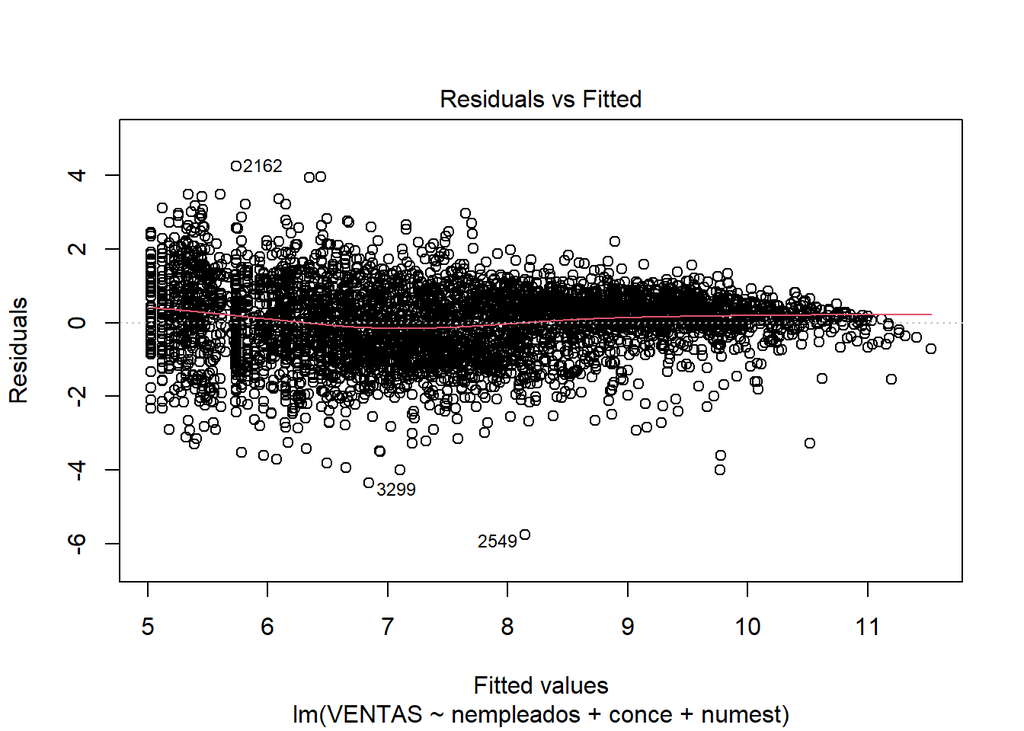

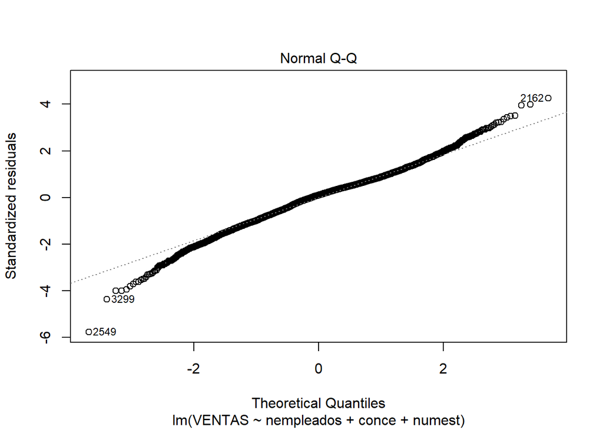

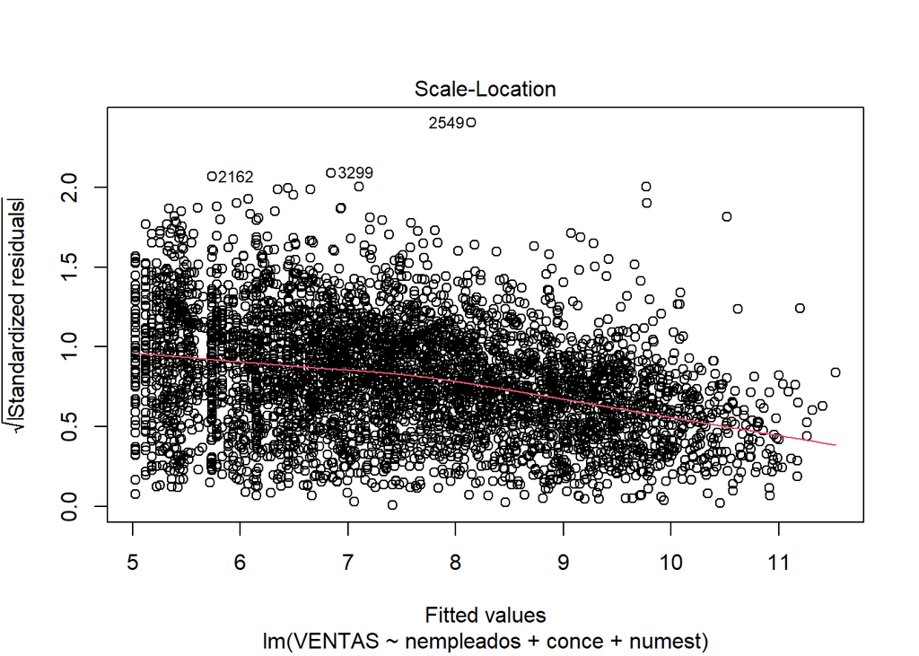

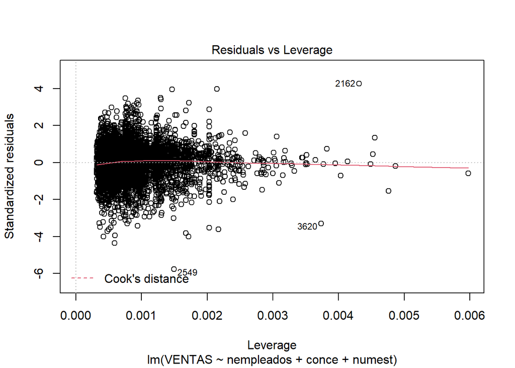

```r
plot(modelofinal)
```

```r
shapiro.test(modelofinal$residuals)
```

```
##
##  Shapiro-Wilk normality test
##
## data:  modelofinal$residuals
## W = 0.98859, p-value < 2.2e-16
```

- Gráfico Residuals Vs fitted . En este gráfico buscamos ver la dispersión respecto de la recta para cada valor predicho (cuánto se alejan de nuestro ajuste). En nuestro caso, se ajustan bastante a la recta, aunque tenemos algún outlier con residuos muy grandes.
- Gráfico Q-Q. Este gráfico muestra cómo se acumulan los residuos respecto de los cuantiles teóricos de una distribución normal. Si la distribución de residuos es normal, los veremos cercanos a la recta. Desviaciones de la recta indican que la distribución de los residuos no es normal. En nuestro gráfico, vemos que la mayoría de los datos están cercanos a la recta pero en los laterales tenemos observaciones que se alejan bastante. De hecho haciendo el test de normalidad a los residuos , vemos que no son normales.
- Gráfico scale-location. Este gráfico es similar al primero, pero los residuos están estandarizados. Vemos algunos outliers también pero a nivel general, está bastante bien.
- Gráfico Residuals VS Leverage. En este gráfico buscamos los puntos influyentes que son aquellos con gran palanca o leverage.Vemos que aquellos puntos que están muy alejados tienen gran influencia sobre el ajuste de la recta. En particular, si estos puntos no se alinean bien con el patrón general de los datos, pueden forzar el modelo hacia un ajuste erróneo. En nuestro caso tenemos algunos puntos outliers pero no nos levanan mucho la curva.

Podemos intentar quitar algunos outliers para ver si mejoramos el modelo:

```r
dfnew2= dfnew [-c(2549,2162),]

newmodel2=lm(formula =  VENTAS ~   nempleados+conce+numest
     , data = dfnew2)
summary(newmodel2)
```

```
##
## Call:
## lm(formula = VENTAS ~ nempleados + conce + numest, data = dfnew2)
##
## Residuals:
##     Min      1Q  Median      3Q     Max
## -4.3498 -0.6279  0.0992  0.6117  3.9908
##
## Coefficients:
##             Estimate Std. Error t value Pr(>|t|)
## (Intercept)  5.01823    0.03479 144.236   <2e-16 ***
## nempleados   1.02932    0.01297  79.352   <2e-16 ***
## conce        0.14323    0.01064  13.457   <2e-16 ***
## numest       0.27546    0.03284   8.387   <2e-16 ***
## ---
## Signif. codes:  0 '***' 0.001 '**' 0.01 '*' 0.05 '.' 0.1 ' ' 1
##
## Residual standard error: 0.9934 on 4380 degrees of freedom
## Multiple R-squared:  0.6869, Adjusted R-squared:  0.6867
## F-statistic:  3203 on 3 and 4380 DF,  p-value: < 2.2e-16
```

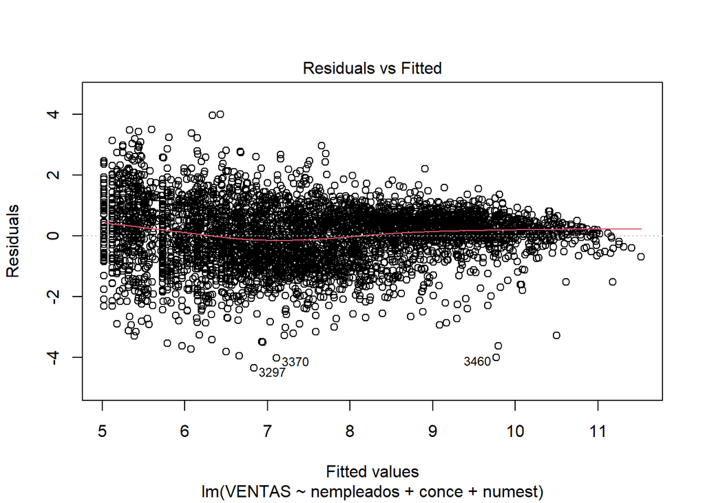

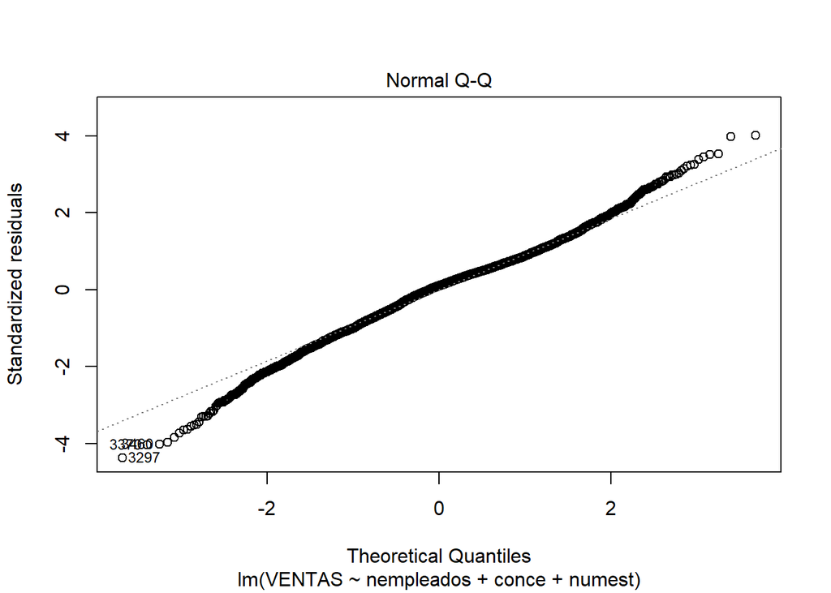

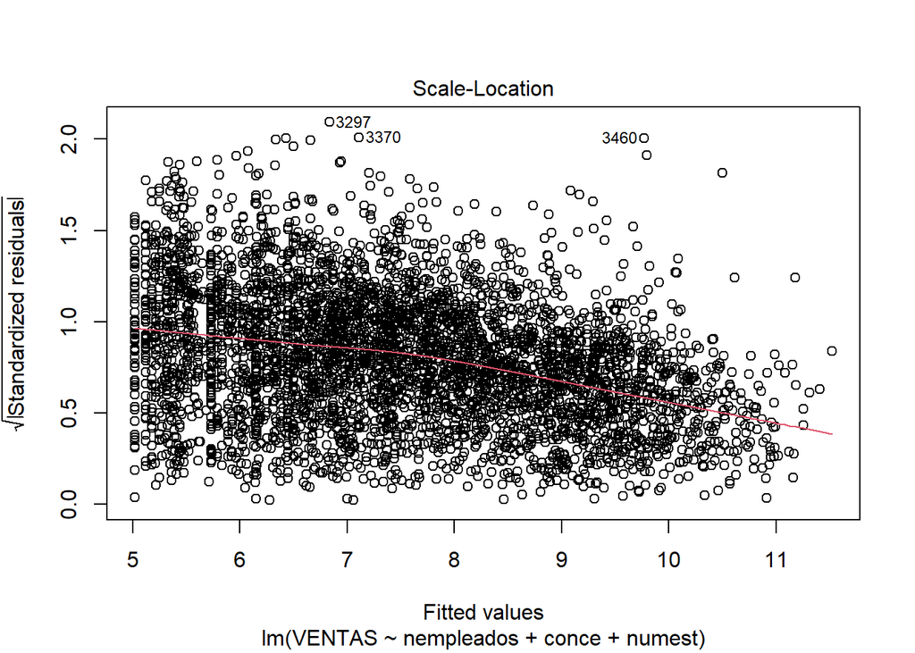

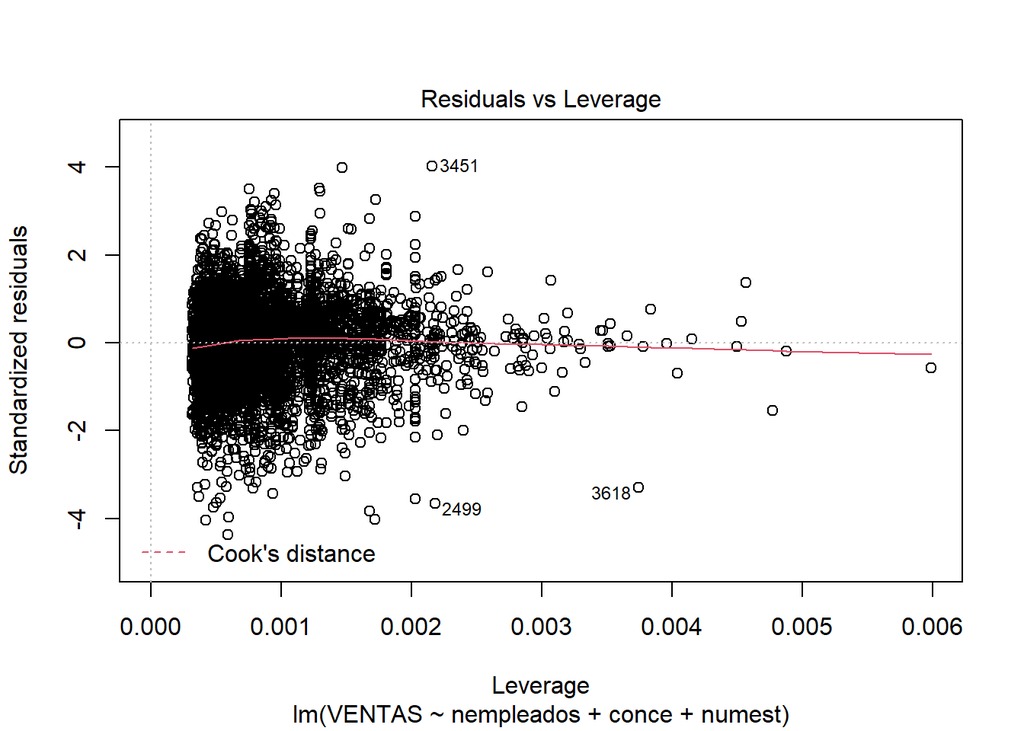

```r
plot(newmodel2)
```

```r
shapiro.test(newmodel2$residuals)
```

```
##
##  Shapiro-Wilk normality test
##
## data:  newmodel2$residuals
## W = 0.98998, p-value < 2.2e-16
```

Observamos que al quitar estos 2 outliers, el R^2 ha subido a 0.6867, pero sigo teniendo en los gráficos de residuos puntos que son outliers. Ademas seguimos teniendo residuos no normales.

Viendo los gráficos , vamos a validar el modelo ya que la mayoria de los puntos tienen unos residuos aceptables y asumibles.

El modelo queda como Ventas= 5.01823 + 1.02932 nempleados + 0.14323 conce + 0.27546 numest

R^2 ajustado de 0.6867

### Modelo predictivo de ventas en Madrid y Barcelona

Creamos un modelo predictivo específico para las ventas en Madrid y Barcelonoa para ver si se consigue una mayor explicabilidad de la variable ventas.

```r
full.modelMadBcn=lm(VENTAS ~ .,dfMadBcn)
summary(full.modelMadBcn)
```

```
##
## Call:
## lm(formula = VENTAS ~ ., data = dfMadBcn)
##
## Residuals:
##     Min      1Q  Median      3Q     Max
## -5.5025 -0.6347  0.1343  0.6209  3.4952
##
## Coefficients:
##                     Estimate Std. Error t value Pr(>|t|)
## (Intercept)        4.6742906  0.3705224  12.615  < 2e-16 ***
## rentabieco         0.0113015  0.0023863   4.736 2.49e-06 ***
## rentabifin         0.0008781  0.0005228   1.679 0.093373 .
## endp               0.1500190  0.0759907   1.974 0.048636 *
## liq                0.0626151  0.0552789   1.133 0.257606
## nempleados         1.0063360  0.0310666  32.393  < 2e-16 ***
## edad              -0.0247615  0.0466841  -0.530 0.595949
## conce              0.0679395  0.0197375   3.442 0.000601 ***
## numest             0.2439049  0.0699589   3.486 0.000511 ***
## estpYes            0.0230789  0.1677878   0.138 0.890625
## GrupoProvinciaBCN  0.0772143  0.0693600   1.113 0.265873
## ---
## Signif. codes:  0 '***' 0.001 '**' 0.01 '*' 0.05 '.' 0.1 ' ' 1
##
## Residual standard error: 1.044 on 1001 degrees of freedom
## Multiple R-squared:  0.687,  Adjusted R-squared:  0.6839
## F-statistic: 219.7 on 10 and 1001 DF,  p-value: < 2.2e-16
```

Vemos que no hay mejoría usando un modelo específicio para Madrid y Barcelona ya que soy capaz de explicar el 68% de la variabilidad de Ventas (un porcentaje en linea con el modelo que teníamos inicaialemente con todas las provincias juntas).